# Régression Multiple - Choix de Modèle

Paul Bastide

2025-11-18

# What we know

## Gaussian Model

### Model:

$$\mathbf{y} = \mathbf{X}\boldsymbol{\beta} + \boldsymbol{\epsilon}$$

- $\mathbf{y}$ **random** vector of $n$ responses
- $\mathbf{X}$ **non random** $n\times p$ matrix of predictors
- $\boldsymbol{\epsilon}$ **random** vector of $n$ errors
- $\boldsymbol{\beta}$ **non random, unknown** vector of $p$ coefficients

### Assumptions:

- (H1) $rg(\mathbf{X}) = p$
- (H2) $\boldsymbol{\epsilon} \sim \mathcal{N}(\mathbf{0}, \sigma^2 \mathbf{I}_n)$

## Distribution of the estimators

Distribution of $\hat{\boldsymbol{\beta}}$:
$$\hat{\boldsymbol{\beta}}
\sim
\mathcal{N}\left(
\boldsymbol{\beta};
\sigma^2 (\mathbf{X}^T\mathbf{X})^{-1}
\right)
\quad
\text{and}
\quad
\frac{\hat{\beta}_k - \beta_k}{\sqrt{\hat{\sigma}^2 [(\mathbf{X}^T\mathbf{X})^{-1}]_{kk}}}
\sim
\mathcal{T}_{n-p}.$$

Distribution of $\hat{\sigma}^2$:
$$\frac{(n-p) \hat{\sigma}^2}{\sigma^2}
\sim
\chi^2_{n-p}.$$

## Student t tests

$$\text{Hypothesis:}
\qquad\qquad
\mathcal{H}_0: \beta_k = 0
\quad
\text{vs}
\quad
\mathcal{H}_1: \beta_k \neq 0$$

$$\text{Test Statistic:}
\qquad\qquad\qquad\qquad
T_k
= \frac{\hat{\beta}_k}{\sqrt{\hat{\sigma}^2_k}}
\underset{\mathcal{H}_0}{\sim}
\mathcal{T}_{n-p}$$

$$\text{Reject Region:}
\qquad\qquad\qquad\qquad\qquad\qquad\qquad\quad\\
\mathbb{P}[\text{Reject} | \mathcal{H}_0 \text{ true}] \leq \alpha
\qquad\qquad\qquad\qquad\qquad\\
\qquad\qquad\qquad \iff \mathcal{R}_\alpha = \left\{ t \in \mathbb{R} ~|~ |t| \geq t_{n-p}(1 - \alpha/2) \right\}$$

$$\text{p value:}\qquad\qquad\qquad\qquad\quad
p = \mathbb{P}_{\mathcal{H}_0}[|T_k| > T_k^{obs}]$$

# Problems with the $t$-test

## Simulated Dataset

$$y_i = -1 + 3 x_{i1} - x_{i2} + \epsilon_i$$

```r
set.seed(1289)

## Predictors
n <- 500
x_1 <- runif(n, min = -2, max = 2)
x_2 <- runif(n, min = -2, max = 2)

## Noise
eps <- rnorm(n, mean = 0, sd = 2)

## Model sim
beta_0 <- -1; beta_1 <- 3; beta_2 <- -1
y_sim <- beta_0 + beta_1 * x_1 + beta_2 * x_2 + eps

## Useless predictor
x_junk_1 <- runif(n, min = -2, max = 2)
```

## Simulated Dataset - Fit

$$y_i = -1 + 3 x_{i1} - x_{i2} + \epsilon_i$$

```r
fit <- lm(y_sim ~ x_1 + x_2 + x_junk_1)
summary(fit)
```

```
Call:
lm(formula = y_sim ~ x_1 + x_2 + x_junk_1)

Residuals:
   Min     1Q Median     3Q    Max
-5.275 -1.453 -0.028  1.371  4.893

Coefficients:
            Estimate Std. Error t value Pr(>|t|)
(Intercept) -0.82789    0.08814  -9.393   <2e-16 ***
x_1          3.01467    0.07546  39.952   <2e-16 ***
x_2         -0.95917    0.07469 -12.842   <2e-16 ***
x_junk_1     0.01534    0.07791   0.197    0.844
---
Signif. codes:  0 '***' 0.001 '**' 0.01 '*' 0.05 '.' 0.1 ' ' 1

Residual standard error: 1.957 on 496 degrees of freedom
Multiple R-squared:  0.7905,    Adjusted R-squared:  0.7893
F-statistic:   624 on 3 and 496 DF,  p-value: < 2.2e-16
```

## Simulated Dataset

$$y_i = -1 + 3 x_{i1} - x_{i2} + \epsilon_i$$

```r
## Other Useless Predictors
p_junk <- 100
x_junk <- matrix(runif(n * p_junk, min = -2, max = 2),
                 ncol = p_junk)

## Data frame
data_junk <- data.frame(y_sim = y_sim,
                        x_junk = x_junk)
```

## Simulated Dataset - Fit - Junk

```r
fit <- lm(y_sim ~ -1 + ., data = data_junk)
summary(fit)
```

```
Call:
lm(formula = y_sim ~ -1 + ., data = data_junk)

Residuals:
     Min       1Q   Median       3Q      Max
-10.8683  -3.0605  -0.2674   2.3554  11.0821

Coefficients:
             Estimate Std. Error t value Pr(>|t|)
x_junk.1    0.2129516  0.1828010   1.165   0.2447
x_junk.2   -0.1075770  0.1919617  -0.560   0.5755
x_junk.3    0.4322452  0.1945466   2.222   0.0269 *
x_junk.4    0.1471909  0.1886285   0.780   0.4357
x_junk.5   -0.1110445  0.1848774  -0.601   0.5484
x_junk.6    0.1276583  0.1829333   0.698   0.4857
x_junk.7    0.0079412  0.1944593   0.041   0.9674
x_junk.8   -0.1126224  0.1854571  -0.607   0.5440
x_junk.9   -0.0560611  0.1918247  -0.292   0.7702
x_junk.10  -0.3215171  0.1883253  -1.707   0.0886 .
x_junk.11  -0.0875118  0.1891359  -0.463   0.6438
x_junk.12  -0.0822697  0.1893373  -0.435   0.6641
x_junk.13   0.0862599  0.1874289   0.460   0.6456
x_junk.14  -0.1322800  0.1895130  -0.698   0.4856
x_junk.15   0.1748496  0.1751535   0.998   0.3188
x_junk.16  -0.2152065  0.1795766  -1.198   0.2315
x_junk.17   0.0987989  0.1868782   0.529   0.5973
x_junk.18  -0.0589122  0.1964012  -0.300   0.7644
x_junk.19   0.0407544  0.1896260   0.215   0.8299
x_junk.20   0.2788872  0.1817698   1.534   0.1257
x_junk.21   0.0780682  0.1901043   0.411   0.6815
x_junk.22   0.0001428  0.1936429   0.001   0.9994
x_junk.23  -0.2146891  0.1860330  -1.154   0.2492
x_junk.24   0.1135748  0.1794805   0.633   0.5272
x_junk.25   0.1797087  0.1849661   0.972   0.3318
x_junk.26  -0.0095168  0.1885643  -0.050   0.9598
x_junk.27  -0.0697160  0.1782409  -0.391   0.6959
x_junk.28  -0.1294379  0.1832707  -0.706   0.4804
x_junk.29  -0.0138295  0.1830424  -0.076   0.9398
x_junk.30   0.2922539  0.1918362   1.523   0.1284
x_junk.31   0.1576348  0.1867874   0.844   0.3992
```

[output cut: 60 more lines]

```
x_junk.92   0.0612578  0.1799226   0.340   0.7337
x_junk.93  -0.0192369  0.1866956  -0.103   0.9180
x_junk.94  -0.0615478  0.1828148  -0.337   0.7365
x_junk.95   0.3675294  0.1778881   2.066   0.0395 *
x_junk.96  -0.0015247  0.1899413  -0.008   0.9936
x_junk.97  -0.1364003  0.1779889  -0.766   0.4439
x_junk.98   0.4422968  0.1888431   2.342   0.0197 *
x_junk.99   0.2366755  0.1815971   1.303   0.1932
x_junk.100  0.0010360  0.1905522   0.005   0.9957
---
Signif. codes:  0 '***' 0.001 '**' 0.01 '*' 0.05 '.' 0.1 ' ' 1

Residual standard error: 4.311 on 400 degrees of freedom
Multiple R-squared:  0.1889,    Adjusted R-squared:  -0.01383
F-statistic: 0.9318 on 100 and 400 DF,  p-value: 0.6596
```

## Simulated Dataset - Fit - Junk

```r
p_values <- summary(fit)$coefficients[, 4]
hist(p_values, col = "lightblue", breaks = 20)
```

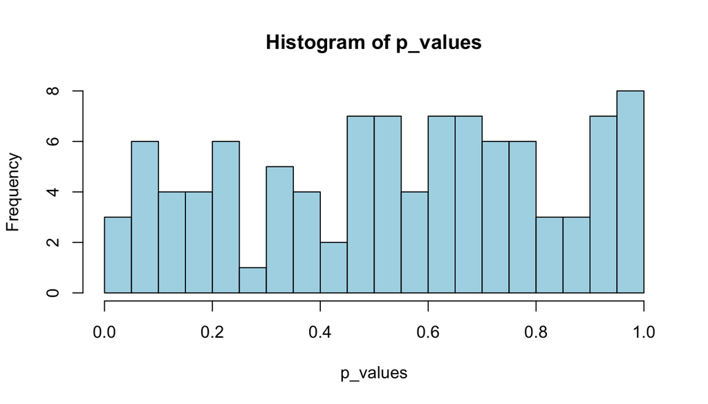

## Simulated Dataset - Fit - Junk

```r
sum(p_values <= 0.05)
```

```
[1] 3
```

```r
summary(fit)$coefficients[p_values <= 0.05, ]
```

```
           Estimate Std. Error  t value   Pr(>|t|)
x_junk.3  0.4322452  0.1945466 2.221807 0.02685525
x_junk.95 0.3675294  0.1778881 2.066071 0.03946512
x_junk.98 0.4422968  0.1888431 2.342138 0.01966334
```

$~$

Reject Region: $\mathbb{P}[\text{Reject} | \mathcal{H}_0 \text{ true}] \leq \alpha$

**Just by chance, about 5% of false discoveries.**

# Joint Distribution of the Coefficients - $\sigma^2$ unknown

## Joint distribution of $\hat{\boldsymbol{\beta}}$

When $\sigma^2$ is known:

$$\hat{\boldsymbol{\beta}}
\sim
\mathcal{N}\left(
\boldsymbol{\beta};
\sigma^2 (\mathbf{X}^T\mathbf{X})^{-1}
\right).$$

When $\sigma^2$ is **unknown**:
$$\frac{1}{p\hat{\sigma}^2}\left(\hat{\boldsymbol{\beta}} - \boldsymbol{\beta}\right)^T (\mathbf{X}^T\mathbf{X})\left(\hat{\boldsymbol{\beta}} - \boldsymbol{\beta}\right)
\sim
\mathcal{F}^p_{n-p}$$

with $\mathcal{F}^p_{n-p}$ the **Fisher** distribution.

## Reminder: Fisher Distribution

Let $U_1 \sim \chi^2_{p_1}$ and $U_2 \sim \chi^2_{p_2}$, $U_1$ and $U_2$ independent. Then
$$F = \frac{U_1/p_1}{U_2/p_2} \sim \mathcal{F}^{p_1}_{p_2}$$

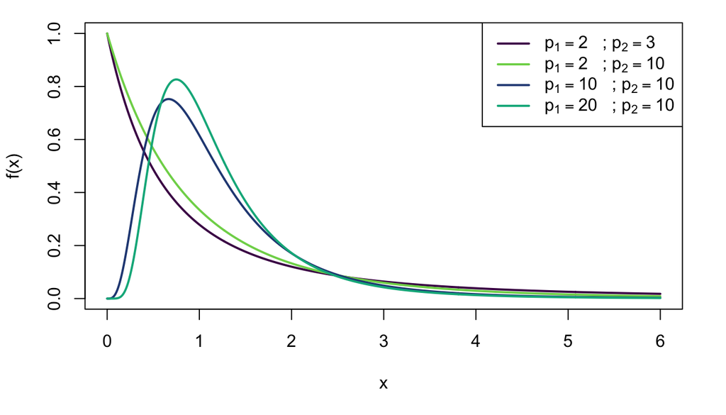

## Joint distribution of $\hat{\boldsymbol{\beta}}$ - Proof - Hints

Let’s show:
$$\frac{1}{p\hat{\sigma}^2}\left(\hat{\boldsymbol{\beta}} - \boldsymbol{\beta}\right)^T (\mathbf{X}^T\mathbf{X})\left(\hat{\boldsymbol{\beta}} - \boldsymbol{\beta}\right)
\sim
\mathcal{F}^p_{n-p}$$

**Hints:**
$$\hat{\boldsymbol{\beta}}
\sim
\mathcal{N}\left(
\boldsymbol{\beta};
\sigma^2 (\mathbf{X}^T\mathbf{X})^{-1}
\right)
\quad
\text{and}
\quad
\frac{(n-p) \hat{\sigma}^2}{\sigma^2}
\sim
\chi^2_{n-p}$$

$$\text{If } \mathbf{X} \sim \mathcal{N}(\boldsymbol{\mu}, \mathbf{\Sigma})
\quad
\text{then}
\quad
(\mathbf{X} - \boldsymbol{\mu})^T \mathbf{\Sigma}^{-1} (\mathbf{X} - \boldsymbol{\mu})
\sim \chi^2_p$$

$$\text{If }
U_1 \sim \chi^2_{p_1}
\text{ and }
U_2 \sim \chi^2_{p_2}
\text{ independent, then }
\frac{U_1/p_1}{U_2/p_2} \sim \mathcal{F}^{p_1}_{p_2}$$

## Joint distribution of $\hat{\boldsymbol{\beta}}$ - Proof

$$\hat{\boldsymbol{\beta}}
\sim
\mathcal{N}\left(
\boldsymbol{\beta};
\sigma^2 (\mathbf{X}^T\mathbf{X})^{-1}
\right)
\qquad\qquad
\\
\qquad\qquad
\implies
\frac{1}{\sigma^2}\left(\hat{\boldsymbol{\beta}} - \boldsymbol{\beta}\right)^T (\mathbf{X}^T\mathbf{X})\left(\hat{\boldsymbol{\beta}} - \boldsymbol{\beta}\right)
\sim
\chi^2_{p}$$

$$\frac{(n-p) \hat{\sigma}^2}{\sigma^2}
\sim
\chi^2_{n-p}
\quad
\text{ independent from } \hat{\boldsymbol{\beta}}$$

Hence:
$$\begin{aligned}
\frac{
\frac{1}{\sigma^2}\left(\hat{\boldsymbol{\beta}} - \boldsymbol{\beta}\right)^T (\mathbf{X}^T\mathbf{X})\left(\hat{\boldsymbol{\beta}} - \boldsymbol{\beta}\right) / p
}{
\frac{(n-p) \hat{\sigma}^2}{\sigma^2} / (n-p)
}
\qquad\qquad\qquad
\\
\qquad\qquad
=
\frac{1}{p\hat{\sigma}^2}\left(\hat{\boldsymbol{\beta}} - \boldsymbol{\beta}\right)^T (\mathbf{X}^T\mathbf{X})\left(\hat{\boldsymbol{\beta}} - \boldsymbol{\beta}\right)
&\sim
\mathcal{F}^p_{n-p}.
\end{aligned}$$

# Global Fisher F-test

## Global Fisher F-test

Hypothesis:
$$\mathcal{H}_0: \beta_1 = \cdots = \beta_p = 0
\quad
\text{vs}
\quad
\mathcal{H}_1: \exists~k ~|~ \beta_k \neq 0$$

Test Statistic:
$$F
= \frac{1}{p\hat{\sigma}^2}\hat{\boldsymbol{\beta}}^T (\mathbf{X}^T\mathbf{X})\hat{\boldsymbol{\beta}}
\underset{\mathcal{H}_0}{\sim}
\mathcal{F}^p_{n-p}$$

Reject Region:
$$\mathbb{P}[\text{Reject} | \mathcal{H}_0 \text{ true}] \leq \alpha
\qquad\qquad\qquad\qquad\qquad\\
\qquad\qquad\qquad
\!\iff\! \mathcal{R}_\alpha = \left\{ f \in \mathbb{R}_+ ~|~ f \geq f^p_{n-p}(1 - \alpha) \right\}$$

p value:$\qquad\qquad p = \mathbb{P}_{\mathcal{H}_0}[F > F^{obs}]$

## Simulated Dataset - Fit - Junk

```r
fit <- lm(y_sim ~ -1 + ., data = data_junk)
f_obs <- summary(fit)$fstatistic
f_obs
```

```
     value      numdf      dendf
  0.931791 100.000000 400.000000
```

```r
p_value_f <- 1 - pf(f_obs[1], f_obs[2], f_obs[3])
p_value_f
```

```
    value
0.6596268
```

We do not reject the null hypothesis that all the (junk) coefficients are zero (phew).

## Fisher F-Test - Geometry

$$\begin{aligned}
F
&= \frac{1}{p\hat{\sigma}^2}\hat{\boldsymbol{\beta}}^T (\mathbf{X}^T\mathbf{X})\hat{\boldsymbol{\beta}}
= \frac{(\mathbf{X}\hat{\boldsymbol{\beta}})^T (\mathbf{X}\hat{\boldsymbol{\beta}}) / p}{\|\hat{\boldsymbol{\epsilon}}\|^2 / (n - p)} \\
&= \frac{\|\hat{\mathbf{y}}\|^2 / p}{\|\hat{\boldsymbol{\epsilon}}\|^2 / (n - p)}
= \frac{\|\hat{\mathbf{y}}\|^2 / p}{\|\mathbf{y} - \hat{\mathbf{y}}\|^2 / (n - p)} \\
\end{aligned}$$

- $\mathcal{H}_0: \beta_1 = \cdots = \beta_p = 0$ i.e. the model is useless.
- If $\|\hat{\boldsymbol{\epsilon}}\|^2$ is **small**, then the error is **small**,  
  and $F$ tends to be **large**, i.e. we tend to **reject** $\mathcal{H}_0$:  
  the model is useful.
- If $\|\hat{\boldsymbol{\epsilon}}\|^2$ is **large**, then the error is **large**,  
  and $F$ tends to be **small**, i.e. we tend to **not reject** $\mathcal{H}_0$:  
  the model is rather useless.

## Geometrical interpretation

**Good model**

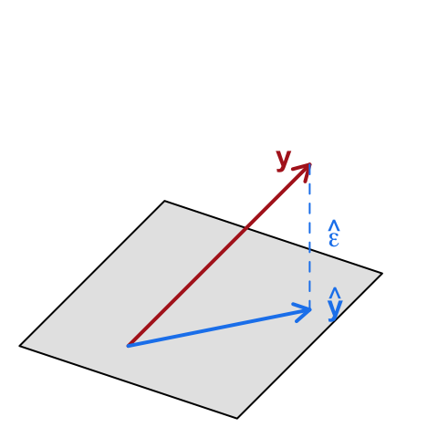

- $\mathbf{y}$ **not too far** from $\mathcal{M}(\mathbf{X})$.
- $\|\hat{\boldsymbol{\epsilon}}\|^2$ **not too large** compared to $\|\hat{\mathbf{y}}\|^2$.
- $F$ tends to be large.

**Bad model**

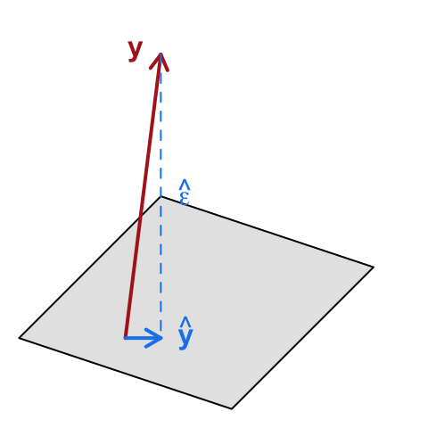

- $\mathbf{y}$ **almost orth.** to $\mathcal{M}(\mathbf{X})$.
- $\|\hat{\boldsymbol{\epsilon}}\|^2$ **rather large** compared to $\|\hat{\mathbf{y}}\|^2$.
- $F$ tends to be small.

## Simulated Dataset - True and Junk

```r
## Data frame
data_all <- data.frame(y_sim = y_sim,
                       x_1 = x_1,
                       x_2 = x_2,
                       x_junk = x_junk)
## Fit
fit <- lm(y_sim ~ ., data = data_all)
## multiple t tests
p_values_t <- summary(fit)$coefficients[, 4]
names(p_values_t[p_values_t <= 0.05])
```

```
[1] "(Intercept)" "x_1"         "x_2"         "x_junk.27"   "x_junk.76"
[6] "x_junk.80"
```

```r
## f test
f_obs <- summary(fit)$fstatistic
p_value_f <- 1 - pf(f_obs[1], f_obs[2], f_obs[3])
p_value_f
```

```
value
    0
```

# Nested Models Fisher F-test

## Nested Models

Can I test ?
$$\begin{aligned}
\mathcal{H}_0&: \beta_{p_0 + 1} = \cdots = \beta_p = 0 &\text{vs}\\
\mathcal{H}_1&: \exists~k\in \{p_0+1, \dotsc, p\} ~|~ \beta_k \neq 0
\end{aligned}$$

i.e. decide between the full model:
$$\mathbf{y} = \mathbf{X}\boldsymbol{\beta} + \boldsymbol{\epsilon}$$

and the nested model:
$$\mathbf{y} = \mathbf{X}_0\boldsymbol{\beta}_0 + \boldsymbol{\epsilon}$$

with
$$\begin{aligned}
\mathbf{X} &= (\mathbf{X}_0 ~ \mathbf{X}_1) &
rg(\mathbf{X}) &= p &
rg(\mathbf{X}_0) &= p_0
\end{aligned}$$

## Geometrical interpretation

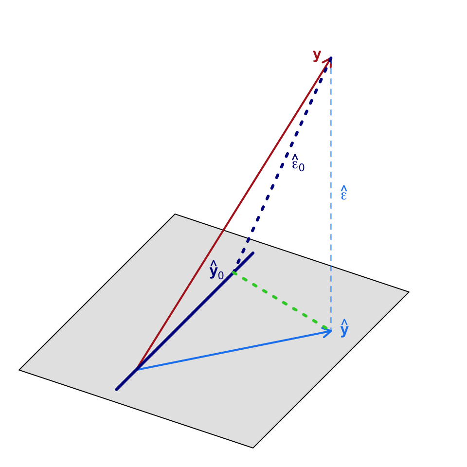

## Nested Models

**Idea**: Compare

- $\|\hat{\mathbf{y}} - \hat{\mathbf{y}}_0\|^2$ distance of $\hat{\mathbf{y}}$ compared to $\hat{\mathbf{y}}_0$ to
- $\|\mathbf{y} - \hat{\mathbf{y}}\|^2$ residual error.

Then:

- If $\|\hat{\mathbf{y}} - \hat{\mathbf{y}}_0\|^2$ **small** compared to $\|\mathbf{y} - \hat{\mathbf{y}}\|^2$, then “$\hat{\mathbf{y}} \approx \hat{\mathbf{y}}_0$” and the null model is enough.
- If $\|\hat{\mathbf{y}} - \hat{\mathbf{y}}_0\|^2$ **large** compared to $\|\mathbf{y} - \hat{\mathbf{y}}\|^2$, then the full model is useful.

## Geometrical interpretation

**Good model**

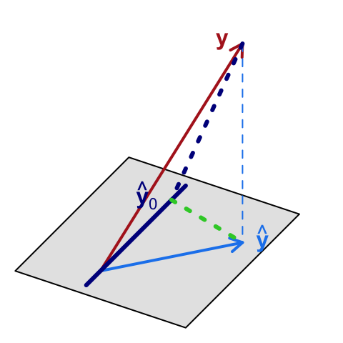

- $\hat{\mathbf{y}}$ **quite different** from $\hat{\mathbf{y}}_0$.
- Full model **does add** information.

**Bad model**

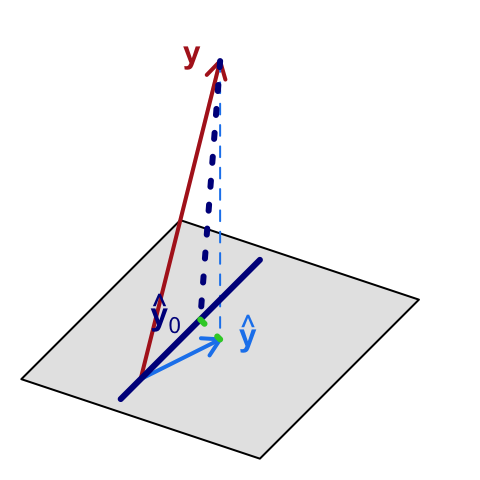

- $\hat{\mathbf{y}}$ **similar** to $\hat{\mathbf{y}}_0$.
- Full model **does not add** much information.

## Nested Models - F test

$$F = \frac{
\|\hat{\mathbf{y}} - \hat{\mathbf{y}}_0\|^2 / (p - p_0)
}{
\|\mathbf{y} - \hat{\mathbf{y}}\|^2 / (n - p)
}$$

- When $F$ is **large**, full model is **useful**.
- When $F$ is **small**, null model is enough.
- Distribution of $F$ ?

## Distribution of $F$ - 1/2

$$F = \frac{
\|\hat{\mathbf{y}} - \hat{\mathbf{y}}_0\|^2 / (p - p_0)
}{
\|\mathbf{y} - \hat{\mathbf{y}}\|^2 / (n - p)
}$$

Let $\mathbf{P}$ projection on $\mathcal{M}(\mathbf{X})$ and $\mathbf{P}_0$ projection on $\mathcal{M}(\mathbf{X}_0)$

$$\begin{aligned}
\hat{\mathbf{y}} - \hat{\mathbf{y}}_0
&= \mathbf{P}\mathbf{y} - \mathbf{P}_0\mathbf{y}
= \mathbf{P}\mathbf{y} - \mathbf{P}_0\mathbf{P}\mathbf{y}\\
&= (\mathbf{I}_n - \mathbf{P}_0) \mathbf{P}\mathbf{y}
= \mathbf{P}_0^\bot \mathbf{P}\mathbf{y}\\
&\in \mathcal{M}(\mathbf{X}_0)^\bot \cap \mathcal{M}(\mathbf{X})
\end{aligned}$$

$$\mathbf{y} - \hat{\mathbf{y}}
= (\mathbf{I}_n - \mathbf{P}) \mathbf{y}
= \mathbf{P}^\bot \mathbf{y}
\in \mathcal{M}(\mathbf{X})^\bot$$

$\hat{\mathbf{y}} - \hat{\mathbf{y}}_0$ and $\mathbf{y} - \hat{\mathbf{y}}$ are **orthogonal**  
i.e. their covariance is zero  
i.e. (Gaussian assumption) they are **independent**.

## Distribution of $F$ - 2/2

From Cochran’s theorem:
$$\frac{1}{\sigma^2}\|\mathbf{y} - \hat{\mathbf{y}}\|^2
= \frac{1}{\sigma^2}\|\mathbf{P}^\bot\mathbf{y}\|^2
= \frac{1}{\sigma^2}\|\mathbf{P}^\bot\boldsymbol{\epsilon}\|^2
\sim \chi^2_{n-p}$$

$$\frac{1}{\sigma^2}\|\hat{\mathbf{y}} - \hat{\mathbf{y}}_0 - \mathbf{P}_0^\bot \mathbf{P}\mathbf{X}\boldsymbol{\beta}\|^2
= \frac{1}{\sigma^2}\|\mathbf{P}_0^\bot \mathbf{P}(\mathbf{y} - \mathbf{X}\boldsymbol{\beta})\|^2
\sim \chi^2_{p-p_0}$$
($\mathbf{P}_0^\bot \mathbf{P}$ is a projection on a space of dimension $p - p_0$)

If $\mathcal{H}_0$ is true, then $\mathbf{P}_0^\bot \mathbf{P}\mathbf{X}\boldsymbol{\beta} = 0$, hence:

$$F = \frac{
\|\hat{\mathbf{y}} - \hat{\mathbf{y}}_0\|^2 / (p - p_0)
}{
\|\mathbf{y} - \hat{\mathbf{y}}\|^2 / (n - p)
}
\underset{\mathcal{H}_0}{\sim}
\mathcal{F}^{p - p_0}_{n - p}.$$

## Nested F test

From Pythagoras’s theorem:
$$\begin{aligned}
\|\mathbf{y} - \hat{\mathbf{y}}_0\|^2
&= \|\mathbf{y} - \mathbf{P}\mathbf{y} + \mathbf{P}\mathbf{y} - \mathbf{P}_0\mathbf{y}\|^2
= \|\mathbf{P}^\bot\mathbf{y} + \mathbf{P}_0^\bot\mathbf{P}\mathbf{y}\|^2\\
&= \|\mathbf{P}^\bot\mathbf{y}\|^2 + \|\mathbf{P}_0^\bot\mathbf{P}\mathbf{y}\|^2
= \|\mathbf{y} - \hat{\mathbf{y}}\|^2 + \|\hat{\mathbf{y}} - \hat{\mathbf{y}}_0\|^2\\
\end{aligned}$$

i.e.
$$\|\hat{\mathbf{y}} - \hat{\mathbf{y}}_0\|^2
= \|\mathbf{y} - \hat{\mathbf{y}}_0\|^2 - \|\mathbf{y} - \hat{\mathbf{y}}\|^2
= RSS_0 - RSS$$

Hence:
$$F = \frac{
\|\hat{\mathbf{y}} - \hat{\mathbf{y}}_0\|^2 / (p - p_0)
}{
\|\mathbf{y} - \hat{\mathbf{y}}\|^2 / (n - p)
}
= \frac{n - p}{p - p_0}\frac{RSS_0 - RSS}{RSS}$$

## Nested F test

To test:
$$\begin{aligned}
\mathcal{H}_0&: \beta_{p_0 + 1} = \cdots = \beta_p = 0 &\text{vs}\\
\mathcal{H}_1&: \exists~k\in \{p_0+1, \dotsc, p\} ~|~ \beta_k \neq 0
\end{aligned}$$

we use the $F$ statistics:
$$F = \frac{
\|\hat{\mathbf{y}} - \hat{\mathbf{y}}_0\|^2 / (p - p_0)
}{
\|\mathbf{y} - \hat{\mathbf{y}}\|^2 / (n - p)
}
= \frac{n - p}{p - p_0}\frac{RSS_0 - RSS}{RSS}
\underset{\mathcal{H}_0}{\sim}
\mathcal{F}^{p - p_0}_{n - p}.$$

## Simulated Dataset - True vs Junk

$$y_i = -1 + 3 x_{i1} - x_{i2} + \epsilon_i$$

```r
## Data frame
data_all <- data.frame(y_sim = y_sim,
                       x_1 = x_1,
                       x_2 = x_2,
                       x_junk = x_junk)
## Fit true
fit_small <- lm(y_sim ~ x_1 + x_2, data = data_all)
## Fit true and junk
fit_all <- lm(y_sim ~ x_1 + x_2 + x_junk.1 + x_junk.2 + x_junk.3, data = data_all)
## Comparison
anova(fit_small, fit_all)
```

```
Analysis of Variance Table

Model 1: y_sim ~ x_1 + x_2
Model 2: y_sim ~ x_1 + x_2 + x_junk.1 + x_junk.2 + x_junk.3
  Res.Df    RSS Df Sum of Sq      F Pr(>F)
1    497 1900.5
2    494 1883.2  3    17.297 1.5124 0.2104
```

## Simulated Dataset - True vs Junk

$$y_i = -1 + 3 x_{i1} - x_{i2} + \epsilon_i$$

```r
## Fit true
fit_small <- lm(y_sim ~ x_1 + x_2, data = data_all)
## Fit all
fit_all <- lm(y_sim ~ ., data = data_all)
## Comparison
anova(fit_small, fit_all)$`Pr(>F)`[2]
```

```
[1] 0.3548787
```

We do not reject the null hypothesis that the first two variables are enough to explain the data.

## Full $F$ test

Assuming that we have an intercept, we often test:
$$\begin{aligned}
\mathcal{H}_0&: \beta_{2} = \cdots = \beta_p = 0 &\text{vs}\\
\mathcal{H}_1&: \exists~k\in \{2, \dotsc, p\} ~|~ \beta_k \neq 0
\end{aligned}$$

The associated $F$ statistics is ($p_0 = 1$):
$$F = \frac{
\|\hat{\mathbf{y}} - \bar{y}\mathbb{1}\|^2 / (p - 1)
}{
\|\mathbf{y} - \hat{\mathbf{y}}\|^2 / (n - p)
}
\underset{\mathcal{H}_0}{\sim}
\mathcal{F}^{p - 1}_{n - p}.$$

That is the default test returned by `R`.

## Full $F$ test

$$y_i = -1 + 3 x_{i1} - x_{i2} + \epsilon_i$$

```r
fit <- lm(y_sim ~ x_1 + x_2)
summary(fit)
```

```
Call:
lm(formula = y_sim ~ x_1 + x_2)

Residuals:
    Min      1Q  Median      3Q     Max
-5.2523 -1.4517 -0.0302  1.3494  4.8711

Coefficients:
            Estimate Std. Error t value Pr(>|t|)
(Intercept) -0.82877    0.08794  -9.424   <2e-16 ***
x_1          3.01415    0.07534  40.008   <2e-16 ***
x_2         -0.95922    0.07462 -12.855   <2e-16 ***
---
Signif. codes:  0 '***' 0.001 '**' 0.01 '*' 0.05 '.' 0.1 ' ' 1

Residual standard error: 1.955 on 497 degrees of freedom
Multiple R-squared:  0.7905,    Adjusted R-squared:  0.7897
F-statistic: 937.8 on 2 and 497 DF,  p-value: < 2.2e-16
```

## One coefficient $F$ test

If $p_0 = p-1$, we test:
$$\begin{aligned}
\mathcal{H}_0&: \beta_p = 0 &\text{vs} \qquad
\mathcal{H}_1&: \beta_p \neq 0
\end{aligned}$$

The associated $F$ statistics is ($p_0 = p-1$):
$$F = \frac{
\|\hat{\mathbf{y}} - \hat{\mathbf{y}}_{-p}\|^2
}{
\|\mathbf{y} - \hat{\mathbf{y}}\|^2 / (n - p)
}
\underset{\mathcal{H}_0}{\sim}
\mathcal{F}^{1}_{n - p}.$$

It can be shown that:
$$F = T^2 \quad \text{with} \quad T = \frac{\hat{\beta}_p}{\hat{\sigma}_p}$$
so that it is equivalent to the $t$-test.

# Summary

## Exact tests

- **t-test**: is *one* individual coefficient $k$ zero ?
  $$\begin{aligned}
  \mathcal{H}_0&: \beta_k = 0 \\
  \mathcal{H}_1&: \beta_k \neq 0
  \end{aligned}
  \quad;\quad
  T_k
  = \frac{\hat{\beta}_k}{\sqrt{\hat{\sigma}^2 [(\mathbf{X}^T\mathbf{X})^{-1}]_{kk}}}
  \underset{\mathcal{H}_0}{\sim}
  \mathcal{T}_{n-p}$$

## Exact tests

- **Global F-test**: are *all* coefficients zero ?
  - *with* intercept
    $$\begin{aligned}
    \mathcal{H}_0&: \beta_{2} = \cdots = \beta_p = 0 \\
    \mathcal{H}_1&: \exists~k\in \{2, \dotsc, p\} ~|~ \beta_k \neq 0
    \end{aligned}
    \quad;\quad
    F = \frac{
    \|\hat{\mathbf{y}} - \bar{y}\mathbb{1}\|^2 / (p - 1)
    }{
    \|\mathbf{y} - \hat{\mathbf{y}}\|^2 / (n - p)
    }
    \underset{\mathcal{H}_0}{\sim}
    \mathcal{F}^{p - 1}_{n - p}$$
  - *no* intercept
    $$\begin{aligned}
    \mathcal{H}_0&: \beta_{1} = \cdots = \beta_p = 0 \\
    \mathcal{H}_1&: \exists~k\in \{1, \dotsc, p\} ~|~ \beta_k \neq 0
    \end{aligned}
    \quad;\quad
    F = \frac{
    \|\hat{\mathbf{y}}\|^2 / p
    }{
    \|\mathbf{y} - \hat{\mathbf{y}}\|^2 / (n - p)
    }
    \underset{\mathcal{H}_0}{\sim}
    \mathcal{F}^{p}_{n - p}$$
- **Nested F-test**: are extra coefficients from the *big model* zero ?
  $${\small
  \begin{aligned}
  \mathcal{H}_0&: \beta_{p_0 + 1} = \cdots = \beta_p = 0\\
  \mathcal{H}_1&: \exists~k\in \{p_0+1, \dotsc, p\} ~|~ \beta_k \neq 0
  \end{aligned}
  ;
  F = \frac{
  \|\hat{\mathbf{y}} - \hat{\mathbf{y}}_0\|^2 / (p - p_0)
  }{
  \|\mathbf{y} - \hat{\mathbf{y}}\|^2 / (n - p)
  }
  = \frac{n - p}{p - p_0}\frac{RSS_0 - RSS}{RSS}
  \underset{\mathcal{H}_0}{\sim}
  \mathcal{F}^{p - p_0}_{n - p}
  }$$

## Exact tests

- Can only test **nested models**.
- Multiple testing issue.
- How to choose relevant predictors from a large pool of predictors ?
  - Marketing
  - Genetics
- Variable Selection

# Variable Selection

## How to choose the “best” model ?

**Model**:
$$y_i = \beta_1 x_{i1} + \dotsb + \beta_p x_{ip} + \epsilon_i$$

**Problem**:  
Can we choose the “best” subset of non-zero $\beta_k$ ?

I.e. Can we find the predictors that really have an impact on $\mathbf{y}$ ?

**Idea**:  
Find a “score” to assess the quality of a given fit.

## Variable selection - $R^2$

$$R^2 = 1 - \frac{RSS}{TSS}$$

```r
## Function to get statistics for one fit
get_stats_fit <- function(fit) {
  sumfit <- summary(fit)
  res <- data.frame(R2 = sumfit$r.squared)
  return(res)
}
```

$$y_i = -1 + 3 x_{i1} - x_{i2} + \epsilon_i$$

## Variable selection - $R^2$

- True fit

```r
get_stats_fit(lm(y_sim ~ x_1 + x_2, data = data_all))
```

```
         R2
1 0.7905255
```

- Bigger fit

```r
get_stats_fit(lm(y_sim ~ x_1 + x_2 + x_junk.1, data = data_all))
```

```
       R2
1 0.79133
```

- Wrong fit

```r
get_stats_fit(lm(y_sim ~ x_1 + x_junk.1, data = data_all))
```

```
         R2
1 0.7252314
```

## Variable selection - $R^2$

```r
## Only one "junk" predictor
data_sub <- data.frame(y_sim = y_sim,
                       x_1 = x_1,
                       x_2 = x_2,
                       x_junk = x_junk_1)
## Fit all possible models
get_all_stats(data_sub)
```

```
            R2          preds
1 0.7208723311            x_1
2 0.1158793338            x_2
3 0.0005972444         x_junk
4 0.7905254867        x_1+x_2
5 0.7208974123     x_1+x_junk
6 0.1164841596     x_2+x_junk
7 0.7905418666 x_1+x_2+x_junk
```

**$R^2$ is not enough.**

## $R^2$ is always increasing

$$R^2 = 1 - \frac{RSS}{TSS}
= 1 - \frac{\|\hat{\epsilon}\|^2}{\|\mathbf{y} - \bar{y} \mathbb{1}\|^2}
= 1 - \frac{\|\mathbf{y} - \mathbf{X}\hat{\boldsymbol{\beta}}\|^2}{\|\mathbf{y} - \bar{y} \mathbb{1}\|^2}$$

If $\mathbf{X}' = (\mathbf{X} ~ \mathbf{x}_{p+1})$ has one more row, then:
$$\begin{aligned}
\|\mathbf{y} - \mathbf{X}'\hat{\boldsymbol{\beta}}'\|^2
& = \underset{\boldsymbol{\beta}' \in \mathbb{R}^{p+1}}{\operatorname{min}}
\|\mathbf{y} - \mathbf{X}'\boldsymbol{\beta}' \|^2\\
& = \underset{\boldsymbol{\beta} \in \mathbb{R}^p\\ \beta_{p+1} \in \mathbb{R}}{\operatorname{min}}
\|\mathbf{y} - \mathbf{X}\boldsymbol{\beta} - \mathbf{x}_{p+1}\beta_{p+1} \|^2\\
& \leq \underset{\boldsymbol{\beta} \in \mathbb{R}^p}{\operatorname{min}}
\|\mathbf{y} - \mathbf{X}\boldsymbol{\beta}\|^2
\end{aligned}$$

$$\text{Hence:}\quad
\|\mathbf{y} - \mathbf{X}'\hat{\boldsymbol{\beta}}'\|^2 \leq \|\mathbf{y} - \mathbf{X}\hat{\boldsymbol{\beta}}\|^2$$

# Penalized Residual Sum of Squares

## Variable selection - $R_a^2$

$$R_a^2 = 1 - \frac{RSS / (n-p)}{TSS / (n-1)}$$

- **Penalize** for the number of predictors $p$.
- **Attention** $p$ includes the intercept (rank of matrix $\mathbf{X}$).

```r
## Function to get statistics
get_stats_fit <- function(fit) {
  sumfit <- summary(fit)
  res <- data.frame(R2 = sumfit$r.squared,
                    R2a = sumfit$adj.r.squared)
  return(res)
}
```

## Variable selection - $R_a^2$

```r
get_all_stats(data_sub)
```

```
            R2          R2a          preds
1 0.7208723311  0.720311834            x_1
2 0.1158793338  0.114103991            x_2
3 0.0005972444 -0.001409588         x_junk
4 0.7905254867  0.789682531        x_1+x_2
5 0.7208974123  0.719774263     x_1+x_junk
6 0.1164841596  0.112928764     x_2+x_junk
7 0.7905418666  0.789274983 x_1+x_2+x_junk
```

**$R_a^2$: adjust for the number of predictors.**

## Adjusted $R_a^2$

$$R_a^2 = 1 - \frac{RSS_p / (n-p)}{TSS / (n-1)}$$

- $RSS_p = \|\mathbf{y} - \mathbf{X}_p\hat{\beta}_p \|^2$ where $rg(\mathbf{X}_p) = p$.
- The larger the better.
- When $p$ is bigger, the fit must be really better for $R_a^2$ to raise.
- Intuitive, but not much theoretical justifications.

## Mallow’s $C_p$

$$C_p = \frac{1}{n} \left( RSS_p + 2 p \hat{\sigma}^2 \right)$$

- Penalize for the number of parameters $p$.
- The **smaller** the better.
- Unbiaised estimate of the *theoretical risk*.

## Simulated Dataset

```r
## Mallow's Cp
Cp <- function(fit) {
  n <- nobs(fit)
  p <- n - df.residual(fit)
  RSS <- deviance(fit)
  return( (RSS + p * RSS / (n - p)) / n)
}
## Function to get statistics
get_stats_fit <- function(fit) {
  sumfit <- summary(fit)
  res <- data.frame(Cp = Cp(fit))
  return(res)
}
```

## Variable selection

```r
## Apply stats to all possible combinations
all_stats <- get_all_stats(data_sub)
all_stats
```

```
         Cp          preds
1  5.085236            x_1
2 16.107190            x_2
3 18.207435         x_junk
4  3.823952        x_1+x_2
5  5.095010     x_1+x_junk
6 16.128558     x_2+x_junk
7  3.831361 x_1+x_2+x_junk
```

Mallow’s $C_p$ is **smallest** for the true model.

# Penalized Log Likelihood

## Maximized Log Likelihood

Recall:
$$\begin{aligned}
(\hat{\boldsymbol{\beta}}_p, \hat{\sigma}^2_{p,ML})
&= \underset{(\boldsymbol{\beta}, \sigma^2) \in \mathbb{R}^{p}\times\mathbb{R}_+^*}{\operatorname{argmax}}
\log L(\boldsymbol{\beta}, \sigma^2 | \mathbf{y})\\
&= \underset{(\boldsymbol{\beta}, \sigma^2) \in \mathbb{R}^{p}\times\mathbb{R}_+^*}{\operatorname{argmax}}
- \frac{n}{2} \log(2\pi\sigma^2)
- \frac{1}{2\sigma^2}\|\mathbf{y} - \mathbf{X}_p\boldsymbol{\beta} \|^2
\end{aligned}$$

And:
$$\hat{\sigma}^2_{p,ML} = \frac{ \|\mathbf{y} - \hat{\mathbf{y}}_p \|^2} {n}
\quad;\quad
\hat{\mathbf{y}}_p = \mathbf{X}_p\hat{\boldsymbol{\beta}}_p$$

Thus:
$$L(\hat{\boldsymbol{\beta}}_p, \hat{\sigma}^2_{ML} | \mathbf{y})
=
\cdots$$

## Maximized Log Likelihood

The maximized likelihood is equal to:
$$L(\hat{\boldsymbol{\beta}}_p, \hat{\sigma}^2_{ML} | \mathbf{y})
=
- \frac{n}{2} \log\left(2\pi\frac{ \|\mathbf{y} - \hat{\mathbf{y}}_p \|^2}{n}\right)
- \frac{1}{2\frac{ \|\mathbf{y} - \hat{\mathbf{y}}_p \|^2}{n}}\|\mathbf{y} - \hat{\mathbf{y}}_p \|^2$$

i.e.
$$\log \hat{L}_p
=
- \frac{n}{2} \log\left(\frac{ \|\mathbf{y} - \hat{\mathbf{y}}_p \|^2}{n}\right)
- \frac{n}{2} \log\left(2\pi\right)
- \frac{n}{2}$$

## Maximized Log Likelihood is increasing

Remember, for any $\eta \subset \eta'$:
$$\|\mathbf{y} - \hat{\mathbf{y}}_{p'}\|^2 \leq \|\mathbf{y} - \hat{\mathbf{y}}_p\|^2$$

Hence $R^2_p = 1 - \frac{\|\mathbf{y} - \hat{\mathbf{y}}_p\|^2}{\|\mathbf{y} - \bar{y} \mathbb{1}\|^2}$ always **increases** when we add a predictor.

Similarly:
$$\log \hat{L}_p
=
- \frac{n}{2} \log\left(\frac{ \|\mathbf{y} - \hat{\mathbf{y}}_p \|^2}{n}\right)
- \frac{n}{2} \log\left(2\pi\right)
- \frac{n}{2}$$
always **increases** when we add some predictors.

## Penalized Maximized Log Likelihood

**Problem:** $\log \hat{L}_p$ always **increases** when we add some predictors.

$\to$ it can not be used for model selection (same as $R^2$).

**Idea**: add a penalty term that depends on the size of the model

$\to$ minimize:
$$- \log \hat{L}_p + f(p) \qquad \text{with f increasing}$$

## Penalized Maximized Log Likelihood

Minimize:
$$- \log \hat{L}_p + f(p) \qquad \text{with f increasing}$$

For nested models:

- $- \log \hat{L}_p$ decreases
- $f(p)$ increases

**Goal**: find $f$ that compensates for the “overfit”, i.e. the noisy and insignificant increase of the likelihood when we add some unrelated predictors.

## Simulated Dataset

```r
## Function to get statistics
get_stats_fit <- function(fit) {
  sumfit <- summary(fit)
  res <- data.frame(minusLogLik = -logLik(fit))
  return(res)
}
```

## Variable selection

```r
## Apply stats to all possible combinations
all_stats <- get_all_stats(data_sub)
all_stats
```

```
  minusLogLik          preds
1    1115.053            x_1
2    1403.284            x_2
3    1433.925         x_junk
4    1043.286        x_1+x_2
5    1115.030     x_1+x_junk
6    1403.113     x_2+x_junk
7    1043.266 x_1+x_2+x_junk
```

When we add “junk” variable, $- \log \hat{L}_p$ decreases, but not a lot.

**Questions**: can we find a good penalty that compensates for this noisy increasing ?

# AIC and BIC

## Akaike Information Criterion - AIC

$$AIC = - 2\log \hat{L}_p + 2 p$$

- $\hat{L}_p$ is the **maximized likelihood** of the model.
- $p$ is the **dimension** of the model.
- The **smaller** the better.
- Asymptotic theoretical guaranties.
- Easy to use and **widely spread**

## Bayesian Information Criterion - BIC

$$BIC = - 2\log \hat{L}_p + p \log(n)$$

$~$

- $\hat{L}_p$ is the **maximized likelihood** of the model.
- $p$ is the **dimension** of the model.
- The **smaller** the better.
- Based on an approximation of the marginal likelihood.
- Easy to use and **widely spread**

See: Lebarbier, Mary-Huard. *Le critère BIC : fondements théoriques et interprétation.* 2004. [[inria-00070685]](https://hal.archives-ouvertes.fr/inria-00070685/)

## AIC vs BIC

$$AIC = - 2\log \hat{L}_p + 2 p$$

$$BIC = - 2\log \hat{L}_p + p \log(n)$$

- Both have asymptotic theoretical justifications.
- BIC penalizes more than AIC $\to$ chooses smaller models.
- Both **widely used**.
- There are some (better) non-asymptotic criteria, see  
  Giraud C. 2014. *Introduction to high-dimensional statistics.*

## Simulated Dataset

```r
## Function to get statistics
get_stats_fit <- function(fit) {
  sumfit <- summary(fit)
  res <- data.frame(minusLogLik = -logLik(fit),
                    AIC = AIC(fit),
                    BIC = BIC(fit))
  return(res)
}
```

## Variable selection

```r
## Apply stats to all possible combinations
all_stats <- get_all_stats(data_sub)
all_stats
```

```
  minusLogLik      AIC      BIC          preds
1    1115.053 2236.105 2248.749            x_1
2    1403.284 2812.567 2825.211            x_2
3    1433.925 2873.850 2886.493         x_junk
4    1043.286 2094.572 2111.430        x_1+x_2
5    1115.030 2238.060 2254.919     x_1+x_junk
6    1403.113 2814.225 2831.084     x_2+x_junk
7    1043.266 2096.533 2117.606 x_1+x_2+x_junk
```

```r
## Select model
apply(all_stats[, -ncol(all_stats)], 2,
      function(x) all_stats[which.min(x), ncol(all_stats)])
```

```
     minusLogLik              AIC              BIC
"x_1+x_2+x_junk"        "x_1+x_2"        "x_1+x_2"
```

## Variable selection - Advertising data

```r
## Advertising data
library(here)
ad <- read.csv(here("data", "Advertising.csv"), row.names = "X")

## Apply stats to all possible combinations
all_stats <- get_all_stats(ad[, c(4, 1:3)])
all_stats
```

```
  minusLogLik       AIC       BIC              preds
1    519.0457 1044.0913 1053.9863                 TV
2    573.3369 1152.6738 1162.5687              radio
3    608.3357 1222.6714 1232.5663          newspaper
4    386.1970  780.3941  793.5874           TV+radio
5    509.8891 1027.7782 1040.9714       TV+newspaper
6    573.2361 1154.4723 1167.6655    radio+newspaper
7    386.1811  782.3622  798.8538 TV+radio+newspaper
```

```r
## Select model
apply(all_stats[, -ncol(all_stats)], 2,
      function(x) all_stats[which.min(x), ncol(all_stats)])
```

```
         minusLogLik                  AIC                  BIC
"TV+radio+newspaper"           "TV+radio"           "TV+radio"
```

# Forward and Backward Search

## Combinatorial problem

$$p \text{ predictors } \to 2^p \text{ possible models.}$$

- Cannot test all possible models.
- “Manual” solution: forward or backward searches.

## Forward search

- Start with the null model (no predictor)
- Try to **add one** predictor ($p$ models to fit)
- Choose the best fitting among the $p$ models.
- Repeat until no more predictors to add.
- Choose best fit with $C_p$, AIC or BIC.

## Forward search - Init

```r
## Full formula
full_formula <- formula(y_sim ~ x_1 + x_2
                        + x_junk.1 + x_junk.2 + x_junk.3
                        + x_junk.4 + x_junk.5 + x_junk.6)

## Complete search
2^8
```

```
[1] 256
```

```r
## No predictors
fit0 <- lm(y_sim ~ 1, data = data_all)
```

## Forward search - Add term

```r
## Add one
library(MASS)
addterm(fit0, full_formula)
```

```
Single term additions

Model:
y_sim ~ 1
         Df Sum of Sq    RSS     AIC
<none>                9072.7 1451.21
x_1       1    6540.3 2532.4  815.17
x_2       1    1051.3 8021.4 1391.63
x_junk.1  1      22.9 9049.8 1451.95
x_junk.2  1      33.0 9039.7 1451.39
x_junk.3  1      60.2 9012.5 1449.88
x_junk.4  1      26.9 9045.8 1451.72
x_junk.5  1      10.0 9062.8 1452.66
x_junk.6  1       8.7 9064.0 1452.73
```

## Forward search - Add term

```r
## Add x_1
fit1 <- lm(y_sim ~ 1 + x_1, data = data_all)
## Add another
addterm(fit1, full_formula)
```

```
Single term additions

Model:
y_sim ~ 1 + x_1
         Df Sum of Sq    RSS    AIC
<none>                2532.4 815.17
x_2       1    631.94 1900.5 673.63
x_junk.1  1     39.55 2492.9 809.30
x_junk.2  1      4.12 2528.3 816.35
x_junk.3  1     12.01 2520.4 814.79
x_junk.4  1      0.00 2532.4 817.17
x_junk.5  1      0.07 2532.4 817.15
x_junk.6  1      8.99 2523.5 815.39
```

## Forward search - Add term

```r
## Add x_1
fit2 <- lm(y_sim ~ 1 + x_1 + x_2, data = data_all)
## Add another
addterm(fit2, full_formula)
```

```
Single term additions

Model:
y_sim ~ 1 + x_1 + x_2
         Df Sum of Sq    RSS    AIC
<none>                1900.5 673.63
x_junk.1  1    7.2994 1893.2 673.71
x_junk.2  1    3.2311 1897.3 674.78
x_junk.3  1    7.4492 1893.0 673.67
x_junk.4  1    0.5146 1900.0 675.50
x_junk.5  1    3.6290 1896.9 674.68
x_junk.6  1    2.4825 1898.0 674.98
```

## Backward search

- Start with the full model (all predictors)
- Try to **remove one** predictor ($p$ models to fit)
- Choose the best fitting among the $p$ models.
- Repeat until no more predictors to remove.
- Choose best fit with $C_p$, AIC or BIC.

## Backward search - Init

```r
## Full formula
fit0 <- lm(y_sim ~ x_1 + x_2
                        + x_junk.1 + x_junk.2 + x_junk.3
                        + x_junk.4 + x_junk.5 + x_junk.6,
           data = data_all)
```

```r
## drop one
dropterm(fit0)
```

```
Single term deletions

Model:
y_sim ~ x_1 + x_2 + x_junk.1 + x_junk.2 + x_junk.3 + x_junk.4 +
    x_junk.5 + x_junk.6
         Df Sum of Sq    RSS     AIC
<none>                1875.5  679.01
x_1       1    6007.5 7883.0 1394.93
x_2       1     592.2 2467.7  814.22
x_junk.1  1       6.7 1882.2  678.78
x_junk.2  1       3.7 1879.2  678.00
x_junk.3  1       6.9 1882.4  678.86
x_junk.4  1       0.8 1876.3  677.22
x_junk.5  1       3.6 1879.1  677.97
x_junk.6  1       3.7 1879.2  678.01
```

## Backward search - Drop term

```r
## drop x_junk.3
fit1 <- lm(y_sim ~ x_1 + x_2
           + x_junk.1 + x_junk.2 +
           + x_junk.4 + x_junk.5 + x_junk.6, data = data_all)
## Drop another
dropterm(fit1)
```

```
Single term deletions

Model:
y_sim ~ x_1 + x_2 + x_junk.1 + x_junk.2 + +x_junk.4 + x_junk.5 +
    x_junk.6
         Df Sum of Sq    RSS     AIC
<none>                1882.4  678.86
x_1       1    6045.2 7927.6 1395.75
x_2       1     595.1 2477.5  814.20
x_junk.1  1       7.9 1890.3  678.95
x_junk.2  1       3.5 1886.0  677.79
x_junk.4  1       0.6 1883.1  677.03
x_junk.5  1       3.7 1886.1  677.84
x_junk.6  1       3.2 1885.7  677.72
```

## Backward search - Drop term

```r
## drop x_junk.4
fit2 <- lm(y_sim ~ x_1 + x_2
           + x_junk.1 + x_junk.2 +
           + x_junk.5 + x_junk.6, data = data_all)
## Drop another
dropterm(fit2)
```

```
Single term deletions

Model:
y_sim ~ x_1 + x_2 + x_junk.1 + x_junk.2 + +x_junk.5 + x_junk.6
         Df Sum of Sq    RSS     AIC
<none>                1883.1  677.03
x_1       1    6075.6 7958.7 1395.71
x_2       1     594.4 2477.5  812.20
x_junk.1  1       7.8 1890.9  677.11
x_junk.2  1       3.4 1886.5  675.93
x_junk.5  1       3.7 1886.8  676.02
x_junk.6  1       3.2 1886.3  675.88
```

## Backward search - Drop term

```r
## drop x_junk.1
fit3 <- lm(y_sim ~ x_1 + x_2
           + x_junk.2 +
           + x_junk.5 + x_junk.6, data = data_all)
## Drop another
dropterm(fit3)
```

```
Single term deletions

Model:
y_sim ~ x_1 + x_2 + x_junk.2 + +x_junk.5 + x_junk.6
         Df Sum of Sq    RSS     AIC
<none>                1890.9  677.11
x_1       1    6067.8 7958.7 1393.71
x_2       1     628.4 2519.3  818.56
x_junk.2  1       3.1 1894.0  675.92
x_junk.5  1       3.9 1894.8  676.14
x_junk.6  1       2.8 1893.7  675.85
```

## Backward search - Drop term

```r
## drop x_junk.2
fit4 <- lm(y_sim ~ x_1 + x_2
           + x_junk.5 + x_junk.6, data = data_all)
## Drop another
dropterm(fit4)
```

```
Single term deletions

Model:
y_sim ~ x_1 + x_2 + x_junk.5 + x_junk.6
         Df Sum of Sq    RSS     AIC
<none>                1894.0  675.92
x_1       1    6098.6 7992.6 1393.83
x_2       1     629.2 2523.3  817.35
x_junk.5  1       4.0 1898.0  674.98
x_junk.6  1       2.9 1896.9  674.68
```

## Backward search - Drop term

```r
## drop x_junk.6
fit5 <- lm(y_sim ~ x_1 + x_2
           + x_junk.5, data = data_all)
## Drop another
dropterm(fit5)
```

```
Single term deletions

Model:
y_sim ~ x_1 + x_2 + x_junk.5
         Df Sum of Sq    RSS     AIC
<none>                1896.9  674.68
x_1       1    6097.8 7994.6 1391.96
x_2       1     635.5 2532.4  817.15
x_junk.5  1       3.6 1900.5  673.63
```

## Backward search - Drop term

```r
## drop x_junk.5
fit6 <- lm(y_sim ~ x_1 + x_2,
           data = data_all)
## Drop another
dropterm(fit6)
```

```
Single term deletions

Model:
y_sim ~ x_1 + x_2
       Df Sum of Sq    RSS     AIC
<none>              1900.5  673.63
x_1     1    6120.9 8021.4 1391.63
x_2     1     631.9 2532.4  815.17
```

## Forward and backward searches

- Both are **heuristics**.
- There are no guaranties that both converge to the same solution.
- No theoretical guaranties on the selected model.
- Model selection is still an active area of research.
  - See e.g: LASSO and other penalized criteria (M2)